# Analiza próbek krwi pacjentów chorych na COVID-19

Damian Szkudlarek

01.12.2020 r.

# Podsumowanie

Zestaw danych to 6120 badań krwi. Każde badanie reprezentowane jest przez 81 atrybutów, z których 7 dotyczy okoliczności badania i pacjenta, a 74 dotyczy samego badania tzn. poziomy wskaźników medycznych. Każdy pacjent mógł być badany wielokrotnie. Największy odsetek pacjentów było badanych 7 razy, natomiast średnio pacjenci oddawali krew 17 razy.

Wśród pacjentów większość stanowili mężczyźni. Również mężczyźni stanowili największy odsetek śmiertelnych przypadków w badanej populacji. Pacjenci przyjęci na oddział szpitalu w Wuhan to w większości osoby starsze. Osoby starsze również, częściej umierały. Podgrupą stanowiącą największy odsetek osób zmarłych są mężczyźni w przedziale wiekowym 61-70 lat.

Pacjenci, którzy przeżyli zakażenie wirusem byli dłużej hospitalizowani, niż osoby które zmarły wskutek zakażenia. Największą różnorodnością w długości przebywania w szpitalu miały osoby w wieku 51-60 lat.

W sekcji Kluczowe wskaźniki biomedyczne przybliżone zostały trzy biomarkery, które w wielu źródłach medycznych są nazywane kluczowymi. Te wskaźniki to dehydrogenaza mleczanowa (LDH), poziom limfocytów oraz wysokoczułe białko C-reaktywne (hs-CRP). Na podstawie ich poziomu można z wyprzedzeniem wskazać czy pacjent zarażony wirusem SARS-CoV-2 przejdzie COVID-19 z ciężkimi objawami (możliwie śmiertelnymi), czy też nie. Wiedza ta, ma za zadanie umożliwić personelowi medycznemu przyznawania pierwszeństwa zasobów ludzkich i sprzętowych osobom z największym zagrożeniem życia.

W raporcie w sekcji Analiza LDH, limfocytów i hs-CRP potwierdzono istotność tych wskaźników medycznych. Histogramy ich wartości obrazują różnice w poziomach, między późniejszymi ozdrowieńcami i denatami.

Między atrybutami zauważalne były korelacje, ale te najsilniejsze są takie z powodów oczywistych dla osoby z podstawowym wykształceniem medycznym. W sekcji dotyczącej korelacji nie zdefiniowano żadnych wniosków, bo niestety żadne nie są widoczne.

Na potrzeby raportu, został zaprojektowany klasyfikator typu `Random Forest`. Model samoczynnie zoptymalizował najbardziej kluczowe elementy. Zestaw danych treningowych i testowych stanowiły oczyszczone z szumu dane wejściowe raportu. Jako zbiór atrybutów do klasyfikacji posłużyły trzy omawiane wcześniej biomarkery. Dokładność predykcji wynosi 94%.

# Biblioteki

```r
library(openxlsx)
library(skimr)
library(dplyr)
library(tidyr)
library(ggplot2)
library(gganimate)
library(caret)
```

# Wczytanie danych

```r
df <- read.xlsx(xlsxFile="data\\wuhan_blood_sample_data_Jan_Feb_2020.xlsx", fillMergedCells = TRUE, sheet = 1)
df$RE_DATE = convertToDateTime(df$RE_DATE)
df$Admission.time = convertToDateTime(df$Admission.time)
df$Discharge.time = convertToDateTime(df$Discharge.time)
```

```r
set.seed(131836)
```

# Opis danych

> Od początku 2020 r. dziesiątki milionów osób zakaziło się wirusem SARS-CoV-2 i ponad milion osób zmarło na chorobę COVID-19 wywołaną tym wirusem. Naukowcy wciąż analizują budowę i właściwości wirusa oraz reakcje organizmu ludzkiego na zarażenie, aby móc lepiej kontrolować rozprzestrzenianie się choroby, projektować szczepionki na SARS-CoV-2 i leki pomagające zwalczać objawy COVID-19. W tym celu zbierane są dane o budowie wirusa na poziomie molekularnym, wykonywane są mikro- i makro-symulacje rozprzestrzeniania się choroby, a także pobierane są próbki krwi chorych. Właśnie próbki krwi pacjentów są punktem wyjścia do niniejszego projektu.

> Dane zostały zebrane między 10. stycznia a 18. lutego 2020 i zawierają informacje o wynikach badań krwi pacjentów przyjętych do szpitala Tongji w Wuhan (Chiny). Sposób zbierania danych oraz podstawowe statystyki zbioru zostały opisane w artykule Tan et al. Dane dane do projektu dostępne są pod adresem: http://www.cs.put.poznan.pl/dbrzezinski/teaching/zed/wuhan_blood_sample_data_Jan_Feb_2020.xlsx. Celem projektu jest analiza i wizualizacja tych danych w poszukiwaniu interesujących zależności.

Data summary

| Name | df |
| --- | --- |
| Number of rows | 6120 |
| Number of columns | 81 |
| _______________________ |  |
| Column type frequency: |  |
| numeric | 78 |
| POSIXct | 3 |
| ________________________ |  |
| Group variables | None |

**Variable type: numeric**

| skim_variable | n_missing | complete_rate | mean | sd | p0 | p75 | p100 |
| --- | --- | --- | --- | --- | --- | --- | --- |
| PATIENT_ID | 0 | 1.00 | 184.78 | 107.37 | 1.00 | 270.00 | 375.00 |
| age | 0 | 1.00 | 59.44 | 16.37 | 18.00 | 71.00 | 95.00 |
| gender | 0 | 1.00 | 1.39 | 0.49 | 1.00 | 2.00 | 2.00 |
| outcome | 0 | 1.00 | 0.47 | 0.50 | 0.00 | 1.00 | 1.00 |
| Hypersensitive.cardiac.troponinI | 5613 | 0.08 | 1223.23 | 5391.61 | 1.90 | 223.75 | 50000.00 |
| hemoglobin | 5145 | 0.16 | 123.12 | 23.74 | 6.40 | 137.00 | 178.00 |
| Serum.chloride | 5145 | 0.16 | 103.14 | 7.75 | 71.50 | 105.65 | 140.40 |
| Prothrombin.time | 5458 | 0.11 | 16.67 | 9.50 | 11.50 | 16.70 | 120.00 |
| procalcitonin | 5661 | 0.07 | 1.11 | 4.66 | 0.02 | 0.41 | 57.17 |
| eosinophils(%) | 5163 | 0.16 | 0.63 | 1.07 | 0.00 | 0.80 | 8.60 |
| Interleukin.2.receptor | 5852 | 0.04 | 907.16 | 788.01 | 61.00 | 1155.50 | 7500.00 |
| Alkaline.phosphatase | 5190 | 0.15 | 82.47 | 46.57 | 17.00 | 95.00 | 620.00 |
| albumin | 5186 | 0.15 | 32.01 | 6.25 | 13.60 | 36.60 | 48.60 |
| basophil(%) | 5163 | 0.16 | 0.21 | 0.22 | 0.00 | 0.30 | 1.70 |
| Interleukin.10 | 5853 | 0.04 | 16.07 | 68.44 | 5.00 | 12.35 | 1000.00 |
| Total.bilirubin | 5190 | 0.15 | 16.70 | 26.57 | 2.50 | 16.78 | 505.70 |
| Platelet.count | 5163 | 0.16 | 184.31 | 104.48 | -1.00 | 248.00 | 558.00 |
| monocytes(%) | 5162 | 0.16 | 6.16 | 4.08 | 0.30 | 8.60 | 53.00 |
| antithrombin | 5790 | 0.05 | 85.32 | 18.29 | 20.00 | 97.00 | 136.00 |
| Interleukin.8 | 5852 | 0.04 | 83.09 | 553.15 | 5.00 | 35.20 | 6795.00 |
| indirect.bilirubin | 5214 | 0.15 | 6.89 | 7.02 | 0.10 | 8.00 | 145.10 |
| Red.blood.cell.distribution.width | 5197 | 0.15 | 13.07 | 1.73 | 10.60 | 13.70 | 27.10 |
| neutrophils(%) | 5163 | 0.16 | 77.60 | 16.64 | 1.70 | 92.30 | 98.90 |
| total.protein | 5189 | 0.15 | 65.30 | 7.63 | 31.80 | 70.45 | 88.70 |
| Quantification.of.Treponema.pallidum.antibodies | 5841 | 0.05 | 0.13 | 0.77 | 0.02 | 0.07 | 11.95 |
| Prothrombin.activity | 5461 | 0.11 | 78.55 | 22.14 | 6.00 | 95.00 | 142.00 |
| HBsAg | 5841 | 0.05 | 8.31 | 42.93 | 0.00 | 0.01 | 250.00 |
| mean.corpuscular.volume | 5163 | 0.16 | 90.39 | 6.50 | 61.60 | 93.90 | 118.90 |
| hematocrit | 5163 | 0.16 | 36.54 | 5.31 | 14.50 | 39.90 | 52.30 |
| White.blood.cell.count | 4993 | 0.18 | 15.60 | 67.75 | 0.13 | 12.72 | 1726.60 |
| Tumor.necrosis.factorα | 5852 | 0.04 | 11.58 | 13.06 | 4.00 | 11.50 | 168.00 |
| mean.corpuscular.hemoglobin.concentration | 5163 | 0.16 | 342.80 | 17.80 | 286.00 | 350.00 | 514.00 |
| fibrinogen | 5554 | 0.09 | 4.29 | 1.89 | 0.50 | 5.48 | 10.78 |
| Interleukin.1ß | NA | NA | NA | NA | NA | NA | NA |
| Urea | 5184 | 0.15 | 9.59 | 9.44 | 0.80 | 11.40 | 68.40 |
| lymphocyte.count | 5163 | 0.16 | 1.02 | 2.06 | 0.00 | 1.31 | 52.42 |
| PH.value | 5736 | 0.06 | 6.48 | 0.73 | 5.00 | 7.29 | 7.57 |
| Red.blood.cell.count | 4993 | 0.18 | 9.29 | 36.31 | 0.10 | 4.65 | 749.50 |
| Eosinophil.count | 5163 | 0.16 | 0.04 | 0.06 | 0.00 | 0.06 | 0.49 |
| Corrected.calcium | 5206 | 0.15 | 2.35 | 0.13 | 1.65 | 2.44 | 2.79 |
| Serum.potassium | 5140 | 0.16 | 4.51 | 0.85 | 2.76 | 4.87 | 12.80 |
| glucose | 5345 | 0.13 | 8.89 | 5.22 | 1.00 | 10.26 | 43.01 |
| neutrophils.count | 5163 | 0.16 | 7.81 | 6.07 | 0.06 | 10.95 | 33.88 |
| Direct.bilirubin | 5190 | 0.15 | 9.89 | 21.41 | 1.60 | 8.28 | 360.60 |
| Mean.platelet.volume | 5258 | 0.14 | 10.91 | 1.09 | 8.50 | 11.50 | 15.00 |
| ferritin | 5837 | 0.05 | 1379.14 | 3454.40 | 17.80 | 1425.25 | 50000.00 |
| RBC.distribution.width.SD | 5197 | 0.15 | 42.44 | 6.30 | 31.30 | 44.70 | 113.30 |
| Thrombin.time | 5554 | 0.09 | 18.17 | 8.89 | 13.00 | 18.38 | 161.90 |
| (%)lymphocyte | 5162 | 0.16 | 15.39 | 12.93 | 0.00 | 24.98 | 60.00 |
| HCV.antibody.quantification | 5841 | 0.05 | 0.12 | 0.24 | 0.02 | 0.09 | 2.09 |
| D-D.dimer | 5490 | 0.10 | 7.94 | 9.21 | 0.21 | 21.00 | 60.00 |
| Total.cholesterol | 5189 | 0.15 | 3.69 | 0.98 | 0.10 | 4.26 | 7.30 |
| aspartate.aminotransferase | 5185 | 0.15 | 46.53 | 103.28 | 6.00 | 42.00 | 1858.00 |
| Uric.acid | 5186 | 0.15 | 276.13 | 151.54 | 43.00 | 333.75 | 1176.00 |
| HCO3- | 5186 | 0.15 | 23.14 | 4.41 | 6.30 | 25.90 | 36.30 |
| calcium | 5141 | 0.16 | 2.08 | 0.16 | 1.17 | 2.19 | 2.62 |
| NT_proBNP | 5645 | 0.08 | 3669.37 | 9695.00 | 5.00 | 2625.00 | 70000.00 |
| Lactate.dehydrogenase | 5186 | 0.15 | 474.23 | 369.14 | 110.00 | 601.75 | 1867.00 |
| platelet.large.cell.ratio | 5258 | 0.14 | 31.77 | 8.57 | 11.20 | 37.20 | 62.20 |
| Interleukin.6 | 5848 | 0.04 | 112.31 | 537.21 | 1.50 | 60.17 | 5000.00 |
| Fibrin.degradation.products | 5790 | 0.05 | 61.35 | 65.65 | 4.00 | 150.00 | 190.80 |
| monocytes.count | 5163 | 0.16 | 0.53 | 1.69 | 0.01 | 0.58 | 39.92 |
| PLT.distribution.width | 5258 | 0.14 | 13.01 | 2.79 | 8.00 | 14.30 | 25.30 |
| globulin | 5190 | 0.15 | 33.24 | 5.51 | 10.10 | 36.50 | 50.60 |
| γ-glutamyl.transpeptidase | 5190 | 0.15 | 55.34 | 69.45 | 3.00 | 58.00 | 732.00 |
| International.standard.ratio | 5461 | 0.11 | 1.31 | 0.81 | 0.84 | 1.33 | 13.48 |
| basophil.count(#) | 5163 | 0.16 | 0.02 | 0.02 | 0.00 | 0.02 | 0.12 |
| 2019-nCoV.nucleic.acid.detection | 5619 | 0.08 | -1.00 | 0.00 | -1.00 | -1.00 | -1.00 |
| mean.corpuscular.hemoglobin | 5163 | 0.16 | 31.00 | 2.91 | 20.40 | 32.20 | 50.80 |
| Activation.of.partial.thromboplastin.time | 5552 | 0.09 | 41.52 | 11.78 | 21.80 | 44.12 | 144.00 |
| High.sensitivity.C-reactive.protein | 5383 | 0.12 | 76.24 | 81.08 | 0.10 | 118.50 | 320.00 |
| HIV.antibody.quantification | 5842 | 0.05 | 0.10 | 0.04 | 0.05 | 0.11 | 0.27 |
| serum.sodium | 5145 | 0.16 | 141.55 | 7.33 | 115.40 | 143.50 | 179.70 |
| thrombocytocrit | 5258 | 0.14 | 0.21 | 0.09 | 0.01 | 0.27 | 0.51 |
| ESR | 5737 | 0.06 | 33.69 | 24.60 | 1.00 | 45.50 | 110.00 |
| glutamic-pyruvic.transaminase | 5189 | 0.15 | 38.86 | 83.77 | 5.00 | 41.00 | 1600.00 |
| eGFR | 5184 | 0.15 | 81.56 | 32.22 | 2.00 | 103.98 | 224.00 |
| creatinine | 5184 | 0.15 | 109.93 | 134.19 | 11.00 | 98.25 | 1497.00 |

**Variable type: POSIXct**

| skim_variable | n_missing | complete_rate | min | max | median | n_unique |
| --- | --- | --- | --- | --- | --- | --- |
| RE_DATE | 14 | 1 | 2020-01-10 19:45:00 | 2020-02-18 17:49:00 | 2020-02-09 12:42:30 | 3091 |
| Admission.time | 0 | 1 | 2020-01-10 15:52:20 | 2020-02-17 21:30:07 | 2020-02-04 15:53:12 | 375 |
| Discharge.time | 0 | 1 | 2020-01-23 09:09:23 | 2020-03-04 16:21:51 | 2020-02-17 21:50:30 | 374 |

Z powyższych zestawień można wyciągnąć wiele wniosków m.in.

W zbiorze obecne są zakodowane atrybuty binarne `gender` i `outcome`; płeć o wartości 1 oznacza mężczyznę, a 2 kobietę, z kolei w przypadku etykiety `outcome` 0 oznacza przeżycie pacjenta, a 1 jego śmierć.

## Kluczowe wskaźniki biomedyczne

Według [artykułu](https://www.nature.com/articles/s42256-020-0180-7) dołączonego do zestawu danych, kluczowe w szacowaniu tego czy pacjent przeżyje są 3 biomarkery – LDH, limfocyty i hs-CRP.

Lidia Stopyra , lekarz szpitala im. Stefana Żeromskiego w Krakowie [pisze](https://www.mp.pl/covid19/ekspertcovid2019/235796,czy-wzrost-ldh-mozna-uznac-za-parametr-bardziej-czuly-niz-crp-w-przypadku-podejrzenia-infekcji-wirusowej-w-tym-sars-cov-2):

> “Zwiększenie wartości LDH ma miejsce w tych infekcjach wirusowych, które przebiegają ze znacznym uszkodzeniem tych komórek, jak np. – ostre wirusowe zapalenia wątroby, mononukleoza zakaźna, zakażenie parwowirusem, COVID-19. […] Zwiększenie stężenia CRP w zakresie 10–100 mg/l jest charakterystyczne dla lokalnych stanów zapalnych, a w zakresie 100–1000 mg/l dla uogólnionych, rozległych stanów zapalnych. W wielu pracach wykazano, że zwiększenie wartości LDH i CRP w infekcjach wirusowych, w tym w infekcji SARS-CoV-2, koreluje zarówno z nasileniem procesów zapalnych i martwiczych, jak i tropizmem wirusa do poszczególnych tkanek, natomiast nie z samym faktem istnienia infekcji wirusowej. Parametry te mają też znaczenie w prognozowaniu rokowania. Na przykład w zakażeniu SARS-CoV-2 wykazano, że zwiększenie CRP >100 mg/l i LDH >245 U/L jest czynnikiem prognostycznym cięższego przebiegu choroby.”

Z kolei Liu et al. doszli w swojej [pracy](https://assets.researchsquare.com/files/rs-40110/v1/78c87491-6f38-4387-8afe-07a080d68e0b.pdf) do wniosku, że hs-CRP jest ważnym wskaźnikiem przy wczesnej prewencji wykrycia stanu zapalnego u pacjentów młodych i w średnim wieku zarażonych COVID-19. Wczesne wykrycie wariacji hs-CRP pozwala ustalić jak poważny będzie przebieg choroby.

Han et. la w [artykule](https://www.researchgate.net/publication/342432180_Lactate_dehydrogenase_an_independent_risk_factor_of_severe_COVID-19_patients_a_retrospective_and_observational_study) podkreśla, że LDH, CRP i limfocyty są silnymi czynnikami ryzyka ciężkiego przebiegu COVID-19. LDH może być bardzo pomocny przy wczesnej detekcji urazów płuc i ciężkich przypadków przebiegu COVID-19.

# Czyszczenie zbioru danych

Zbiór danych nie jest idealny. Za zupełnie bezwartościowe uznać można wiersze, w których brakuje każdego badania. Takie wiersze można rozpoznać również po tym, że data pobrania krwi (RE_DATE) jest wartością brakującą.

```r
identical(
    df %>% filter(is.na(RE_DATE)),
    df %>% filter(across(-(1:7),is.na))
  )
```

```
## [1] TRUE
```

Jak widać brak wartości `RE_DATE` wiąże się z brakiem wartości wszystkich biomarkerów. Zbędne wiersze zostały usunięte ze zbioru, żeby nie produkować choćby minimalnego szumu.

```r
df <- df %>% filter(!is.na(RE_DATE))
```

Część rekordów zawiera pewną niespójność dotyczącą czasu badania i czasu zwolnienia pacjenta ze szpitala. Przypadków, w których badanie krwi było wykonane po wypisaniu pacjenta, znalazło się 71.

```r
df %>% filter(RE_DATE > Discharge.time) %>% select(1:7) %>% head() %>% knitr::kable()
```

| PATIENT_ID | RE_DATE | age | gender | Admission.time | Discharge.time | outcome |
| --- | --- | --- | --- | --- | --- | --- |
| 17 | 2020-02-18 08:51:00 | 27 | 2 | 2020-02-01 19:27:38 | 2020-02-17 16:15:03 | 0 |
| 38 | 2020-02-13 18:04:00 | 73 | 2 | 2020-02-10 11:32:33 | 2020-02-13 17:54:00 | 0 |
| 38 | 2020-02-13 18:35:00 | 73 | 2 | 2020-02-10 11:32:33 | 2020-02-13 17:54:00 | 0 |
| 38 | 2020-02-13 18:41:00 | 73 | 2 | 2020-02-10 11:32:33 | 2020-02-13 17:54:00 | 0 |
| 38 | 2020-02-13 18:57:00 | 73 | 2 | 2020-02-10 11:32:33 | 2020-02-13 17:54:00 | 0 |
| 43 | 2020-02-18 13:56:00 | 70 | 1 | 2020-02-10 04:32:37 | 2020-02-18 12:07:43 | 0 |

Takie rekordy nie wpływają negatywnie na jakość całego zbioru, ale można je usunąć, żeby dane były bardziej spójne.

Wiele rekordów cechuje się brakiem wartości w większości atrybutów. Zjawisko to przedstawione zostało poniżej.

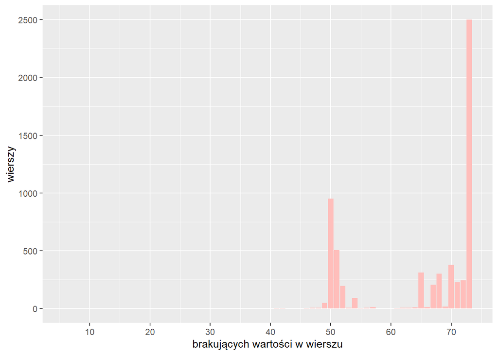

Niekompletne dane mogą okazać się niewystarczające do poprawnej klasyfikacji ciężkich przypadków zachorowań, a badanie atrybutów może okazać się bezowocne z powodu małej liczby próbek.

# Analiza danych

Każdy pacjent mógł być badany wielokrotnie. Największy odsetek pacjentów było badanych 7 razy, natomiast średnio pacjenci oddawali krew 17 razy. Maksymalnie przeprowadzono 59 testów na jednym pacjencie – jest to przypadek szczególny, znacząco odstający od reszty. Wykres poniżej przedstawia rozkład wykonanych badań na pacjentach.

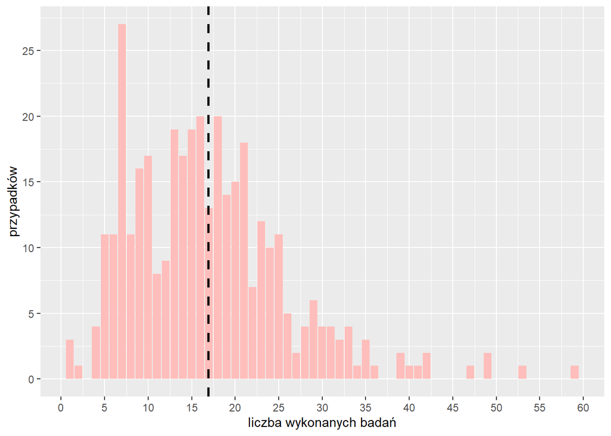

## Liczność pacjentów

W trakcie eksperymentu przebadanych zostało 361 pacjentów, wśród nich rozróżnić można 149 kobiet i 212 mężczyzn. Liczność pacjentów ze względu na płeć przedstawia poniższy wykres.

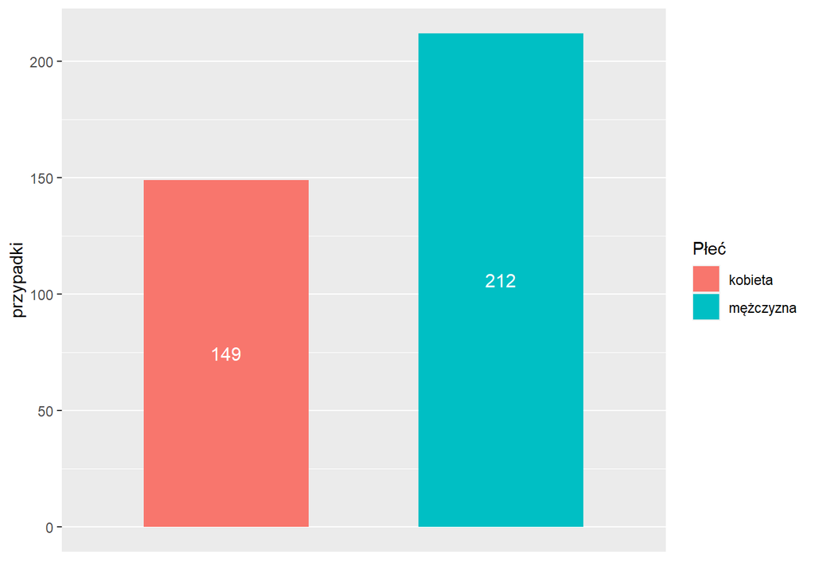

## Śmiertelność pacjentów

Pobyt w szpitalu przeżyła podobna liczba mężczyzn i kobiet, jednakże kobiet w tej grupie było więcej. Znaczną różnicę można zauważyć w przypadku osób zmarłych, w której mężczyźni stanowią grupę dominującą. Śmiertelność wśród płci przedstawiono na następnym wykresie.

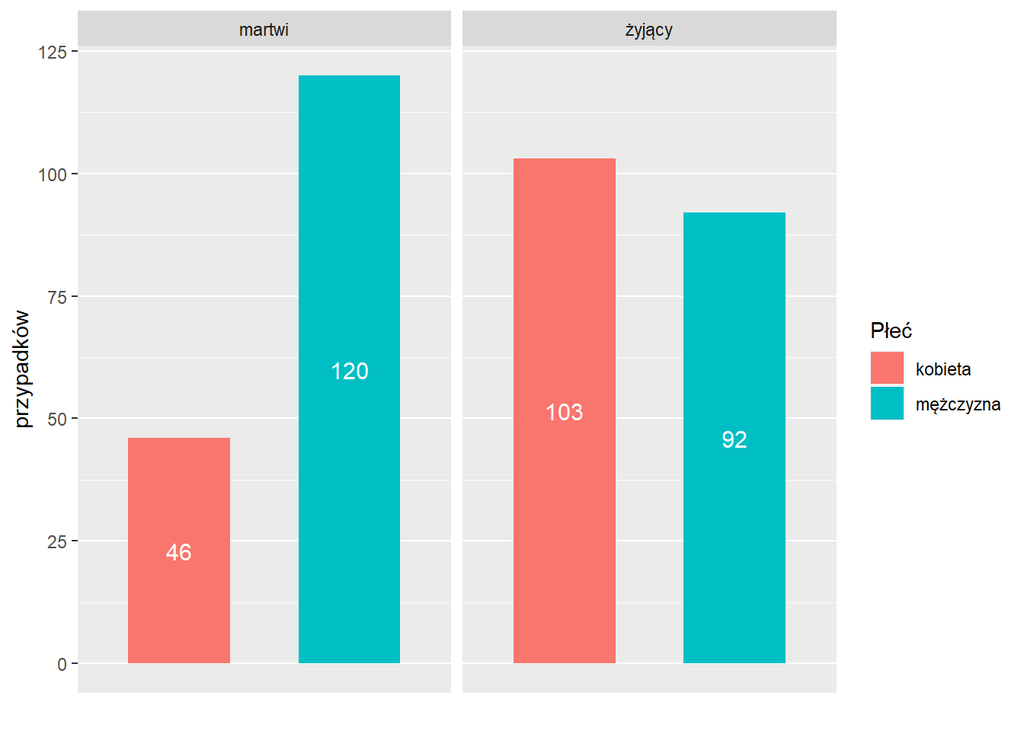

## Rozkład wieku wśród pacjentów

Poniżej znajduje się rozkład wieku pacjentów wśród obu płci.

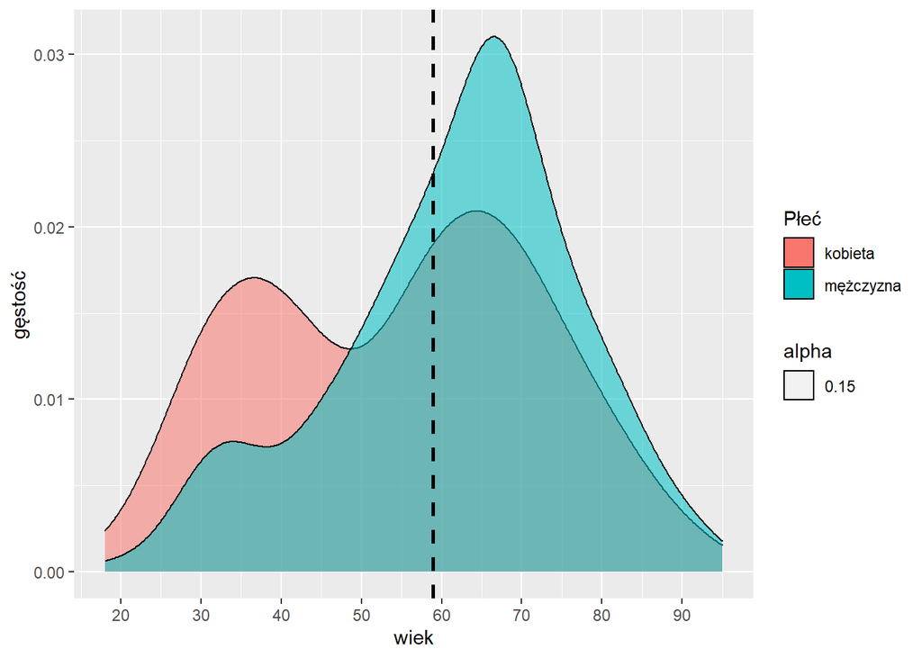

Wynika z niego, że większość mężczyzn jest w starszym wieku, przy czym najwięcej należy do grupy 60-70 lat.  
Najmłodszy mężczyzna ma 19 lat, najstarszy 95. Średnio mężczyźni mają 62 lat.

Kobiety rozbite są na dwie większe grupy wiekowe – duży odsetek z nich ma blisko 35 lub 65 lat, przy czym więcej pacjentek jest w podeszłym wieku. Najmłodsza kobieta ma 18 lat, najstarsza 95. Średnio kobiety mają 55 lat.

Średni pacjent, bez względu na płeć ma 59 lat.

## Czas hospitalizacji

Pacjenci nie przebywali w szpitalu przez stały okres czasu. Liczba dni, którą każdy z nich spędził w szpitalu była oczywiście zależna od stanu zdrowia, ale można zauważyć pewne zależności od innych cech. Kolejny wykres przedstawia czas hospitalizacji dla różnych przedziałów wiekowych.

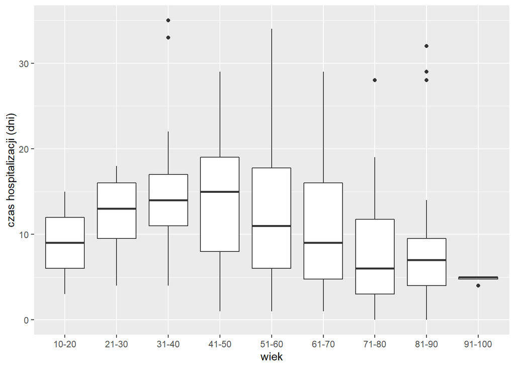

Większość pacjentów przebywała w szpitalu w ciągłym zakresie dni, ale w niektórych grupach wiekowych obecne są przypadki odstające.

Następny wykres ilustruje podobną zależność, lecz teraz czas hospitalizacji zestawiony został ze śmiertelnością.

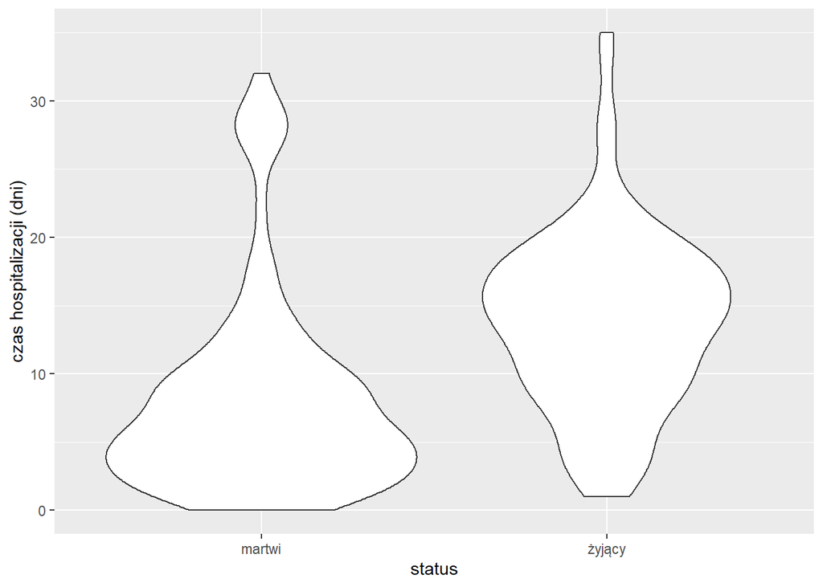

Pacjenci, którzy zmarli w szpitalu, statystycznie spędzili w nim około tydzień, zapewne z powodu ciężkiego przebiegu choroby. Na wykresie widać też niemałe skupisko przypadków, którzy byli hospitalizowani blisko miesiąc.

Większość osób, która przeżyła, spędziła w szpitalu dwa tygodnie lub mniej. Znacznie mniejsza część pacjentów była hospitalizowana ponad 20 dni.

## Liczba śmiertelnych przypadków wśród grup wiekowych

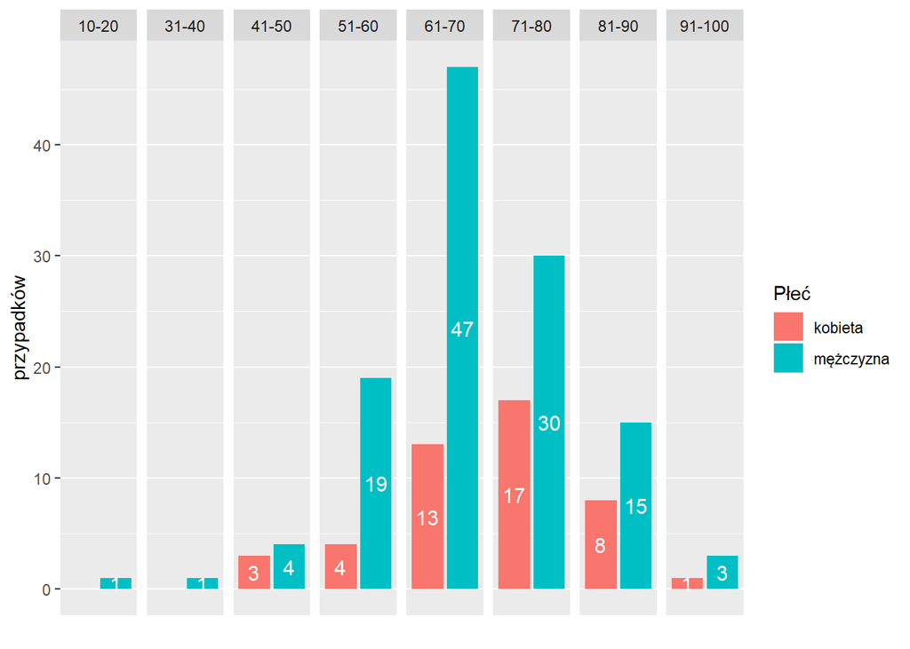

## Analiza LDH, limfocytów i hs-CRP

W sekcji Kluczowe wskaźniki biomedyczne przytoczone zostały opinie świata nauki na temat tytułowych biomarkerów. Poniżej porównane zostały poziomy tych wskaźników u osób, u których zakażenie koronawirusem zakończyło się śmiercią, z osobami, które przeżyły.

Następny wykres przedstawia zmienne w czasie poziomy LDH, uśrednione na poziomie dnia.

[figure not shown]

Kolejny wykres przedstawia histogram wartości LDH wśród pacjentów.

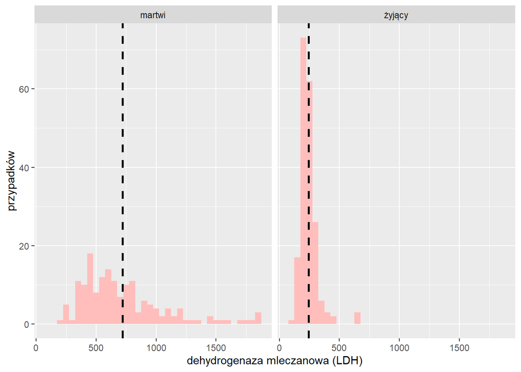

Warto zauważyć, że pacjenci, którzy przeżyli mieli średnio LDH na poziomie 243 jednostek, a pacjenci, którzy nie przeżyli na poziomie 721 jednostek. Wśród pacjentów z nieśmiertelnym przebiegiem choroby LDH skupiało się głównie zakresie [150-400], pojedyncze przypadki przekraczały 500 jednostek.

Pacjenci, którzy nie przeżyli mieli bardzo szerokie spektrum wartości LDH. Trudno w tym przypadku mówić o tak wyraźnych skupiskach, jednakże większość badanych nie przekraczała granicy 1000 jednostek. W tej mniejszości przekraczającej granicę znalazło się 27 pacjentów, wśród których 3 miało LDH na poziomie 1867.  
Kolejny wykres przedstawia histogram wartości procentowych limfocytów wśród pacjentów.

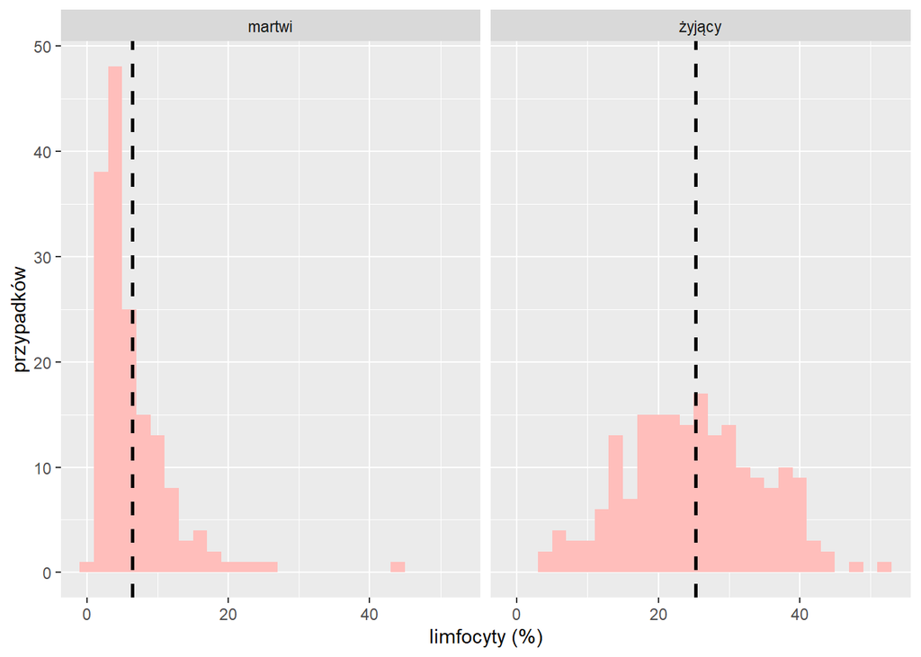

W prawej sekcji, przedstawiającej poziomy limfocytów u ozdrowieńców, można zauważyć, że rozkład wartości nie był skupiony w jednym miejscu. Pacjenci wykazywali się odpornością na różnym poziomie.

Odwrotne wnioski można wysunąć u przypadków śmiertelnych, wśród których wartości limfocytów były skupione w okolicy 5%. Zdecydowana większość badań wykazała poziom limfocytów poniżej 20%.  
Na następnym wykresie znajduje się histogram wartości markera hs-CRP.

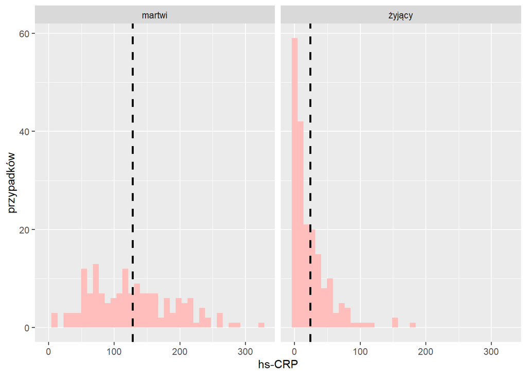

Kolejny raz, zauważyć można podobne kształty histogramów.

Niskie poziomy hs-CRP świadczą o braku wyraźnej infekcji i stanu zapalnego, stąd u pacjentów z mniej poważnym przypadkiem zachorowania na COVID-19, wartości tego wskaźnika są skupione i oscylują bliżej dolnej granicy.

Pacjenci, którzy zginęli w wyniku zachorowania na koronawirusa, przejawiali wysokie wartości hs-CRP, ale trudno określić jednoznaczne skupienie wartości.

# Korelacja między atrybutami

Fakt, że wzrost jednego wskaźnika idzie w parze ze wzrostem lub spadkiem innego wskaźnika nie jest szokujący. Szczególnie, że niektóre biomarkery występują w dwóch jednostkach – mierzymy procentowy poziom limfocytów, ale osobno podajemy też ich liczność.

Poniższa tabela przedstawia pary wskaźników, które są najbardziej ze sobą skorelowane (według miary Pearsona). Atrybut `rows` przedstawia liczbę badań, w których występują oba wskaźniki – jest on brany pod uwagę, po to by wyeliminować wskaźniki o wysokiej korelacji przy bardzo niskiej liczbie próbek.

| col1 | col2 | coef | rows |
| --- | --- | --- | --- |
| Prothrombin.time | International.standard.ratio | 0.9941983 | 659 |
| Mean.platelet.volume | platelet.large.cell.ratio | 0.9931216 | 862 |
| Platelet.count | thrombocytocrit | 0.9816657 | 862 |
| Total.bilirubin | Direct.bilirubin | 0.9807178 | 930 |
| neutrophils(%) | (%)lymphocyte | -0.9794069 | 957 |
| platelet.large.cell.ratio | PLT.distribution.width | 0.9492975 | 862 |
| D-D.dimer | Fibrin.degradation.products | 0.9480807 | 330 |
| hemoglobin | hematocrit | 0.9479940 | 957 |
| Mean.platelet.volume | PLT.distribution.width | 0.9411270 | 862 |
| lymphocyte.count | monocytes.count | 0.9154199 | 957 |

Niektóre z powyższych rekordów zostały przedstawione w formie wykresów poniżej.

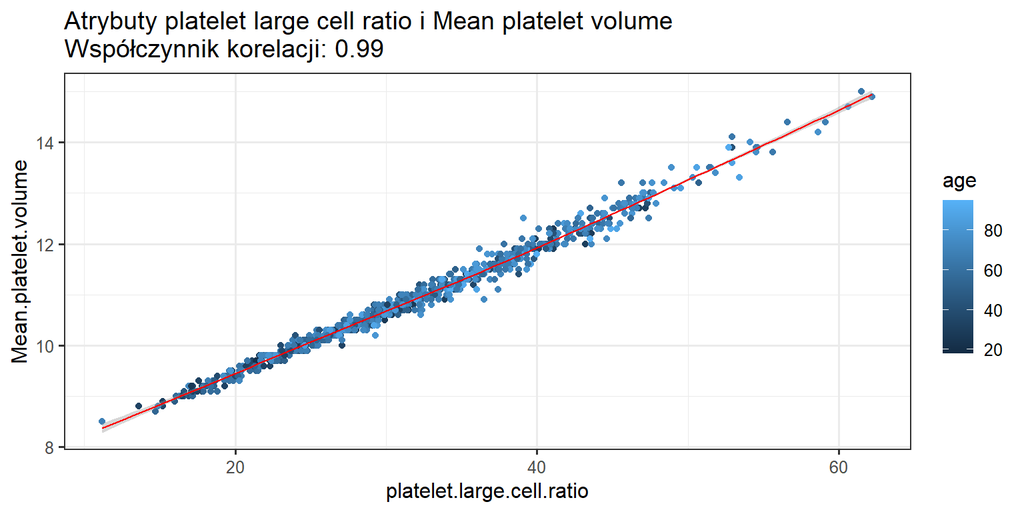

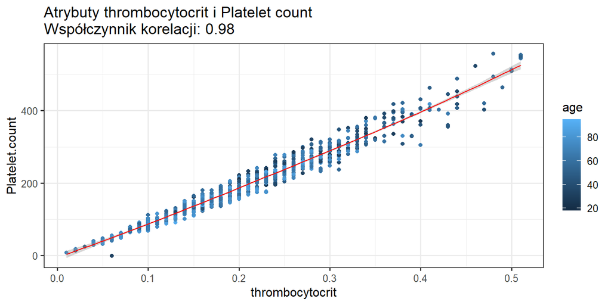

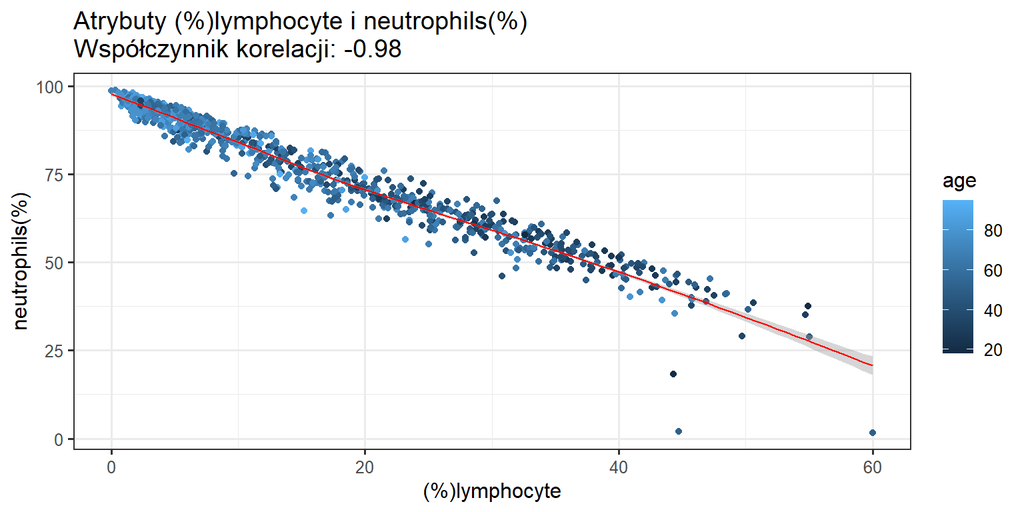

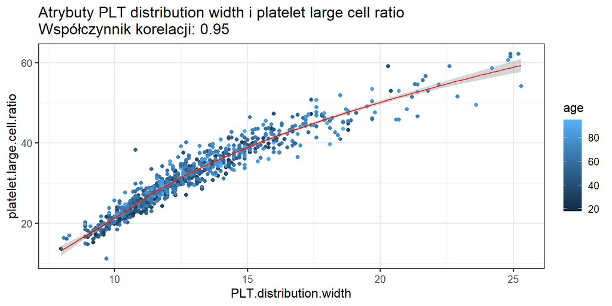

# Klasyfikacja

Na potrzeby klasyfikacji etykieta `outcome` zostanie przemianowana na `danger`, po to aby etykieta dostarczona modelowi odpowiadała wyraźniej na pytanie tak/nie. Zadawanym pytanie ma być „Czy istnieje zagrożenie życia?”.

Jeżeli klasyfikator miałby oprzeć się na trzech atrybutach opisywanych we wcześniejszych sekcjach – LDH, limfocyty i hs-CRP to zbiór danych w obecnej postaci wyglądałby tak:

| danger | LDH | hs_CRP | lymphocytes |
| --- | --- | --- | --- |
| no | 243 | 10.9 | 30.5 |
| yes | 1738 | 113.1 | 2.3 |
| yes | 608 | 133.5 | 3.1 |
| yes | 604 | 293.0 | 2.3 |
| yes | 1126 | 320.0 | 3.7 |

To tylko 5 rekordów. Wynika to z tego, że pacjenci mogli mieć badane różne cechy w ciągu dnia o różnych godzinach, tzn. LDH mogło być badane o 9:00, a limfocyty o 14:00. W zbiorze zostało to zapisane w osobnych rekordach, więc te dwa wskaźniki nie zostałyby powiązane i nie trafiłyby na wejście klasyfikatora.  
Na potrzeby eksperymentu, badania każdego pacjenta zostały pogrupowane na poziomie dnia, a wartości kolejnych atrybutów zostały uśrednione, co wpływa korzystnie na kompletność danych w każdym rekordzie.

```r
merged <- df %>%
  mutate(RE_DATE = as.Date(RE_DATE)) %>%
  group_by(PATIENT_ID, RE_DATE) %>%
  summarise(across(-(1:4), ~mean(.x, na.rm=TRUE))) %>%
  ungroup()
```

W takiej postaci znalezienie wszystkich trzech, kluczowych biomarkerów jest bardziej owocne, tzn. znaleziono 657 wyników. Liczność badań przedstawicieli obu klas (przeżycie i śmierć) jest stosunkowo zbliżona – 341 badań pacjentów, którzy przeżyli i 316 badań pacjentów, którzy zmarli.

| danger | LDH | hs_CRP | lymphocytes |
| --- | --- | --- | --- |
| no | 306 | 43.1 | 22.6 |
| no | 250 | 3.6 | 25.9 |
| no | 198 | 2.6 | 28.7 |
| no | 738 | 27.4 | 7.5 |
| no | 328 | 42.3 | 19.1 |
| no | 269 | 3.6 | 33.1 |
| no | 338 | 108.2 | 12.5 |
| no | 249 | 14.5 | 21.5 |
| no | 195 | 7.0 | 37.9 |
| no | 179 | 0.8 | 30.5 |

Podsumowanie danych dla obu klas:

|  | LDH | hs_CRP | lymphocytes |
| --- | --- | --- | --- |
|  | Min. : 110.0 | Min. : 0.10 | Min. : 0.00 |
|  | 1st Qu.: 220.0 | 1st Qu.: 5.40 | 1st Qu.: 4.10 |
|  | Median : 344.0 | Median : 50.40 | Median :11.70 |
|  | Mean : 461.5 | Mean : 75.23 | Mean :15.45 |
|  | 3rd Qu.: 586.0 | 3rd Qu.:118.10 | 3rd Qu.:24.70 |
|  | Max. :1867.0 | Max. :320.00 | Max. :55.00 |

Podsumowanie danych dla pacjentów, którzy przeżyli:

|  | LDH | hs_CRP | lymphocytes |
| --- | --- | --- | --- |
|  | Min. :110.0 | Min. : 0.1 | Min. : 3.00 |
|  | 1st Qu.:190.0 | 1st Qu.: 1.6 | 1st Qu.:15.00 |
|  | Median :230.0 | Median : 7.0 | Median :23.70 |
|  | Mean :252.9 | Mean : 24.7 | Mean :24.15 |
|  | 3rd Qu.:290.0 | 3rd Qu.: 33.2 | 3rd Qu.:32.70 |
|  | Max. :817.0 | Max. :236.8 | Max. :55.00 |

Podsumowanie danych dla pacjentów, którzy zmarli:

|  | LDH | hs_CRP | lymphocytes |
| --- | --- | --- | --- |
|  | Min. : 197.0 | Min. : 3.9 | Min. : 0.000 |
|  | 1st Qu.: 434.8 | 1st Qu.: 65.0 | 1st Qu.: 2.438 |
|  | Median : 584.0 | Median :113.5 | Median : 4.050 |
|  | Mean : 686.6 | Mean :129.8 | Mean : 6.062 |
|  | 3rd Qu.: 801.5 | 3rd Qu.:183.3 | 3rd Qu.: 7.100 |
|  | Max. :1867.0 | Max. :320.0 | Max. :44.300 |

## Podział zbioru

Zbiory treningowe i testowy zostały podzielone w stosunku 75:25.

```r
trainIndexes <- createDataPartition(
          y = biomarkers$danger,
          p = .75,
          list = FALSE
        )

training <- biomarkers[trainIndexes,]
testing  <- biomarkers[-trainIndexes,]
```

## Model

Model treningowy, na którym oparta zostanie predykcja przeżycia pacjenta to Random Forest.

Schematem uczenia jest dziesięciokrotna walidacja krzyżowa z czterema powtórzeniami.

Random Forest uczy się na danych treningowych i automatycznie optymalizuje wartość `mtry` do wartości 3. Parametr `ntree` został dobrany holistycznie.

```r
set.seed(131836)

ctrl <- trainControl(
    method = "repeatedcv",
    number = 10,
    repeats = 4)

fit <- train(danger ~ .,
             data = training,
             method = "rf",
             preProc = c("center", "scale"),
             trControl = ctrl,
             ntree = 15)
fit
```

```
## Random Forest
##
## 493 samples
##   3 predictor
##   2 classes: 'no', 'yes'
##
## Pre-processing: centered (3), scaled (3)
## Resampling: Cross-Validated (10 fold, repeated 4 times)
## Summary of sample sizes: 444, 443, 444, 443, 444, 444, ...
## Resampling results across tuning parameters:
##
##   mtry  Accuracy   Kappa
##   2     0.9082143  0.8163610
##   3     0.9086616  0.8171245
##
## Accuracy was used to select the optimal model using the largest value.
## The final value used for the model was mtry = 3.
```

## Predykcja

```r
predicted <- predict(fit, newdata = testing)
confMatrix <- confusionMatrix(data = predicted, testing$danger)
```

Macierz pomyłek:

|  | no | yes |
| --- | --- | --- |
| no | 80 | 4 |
| yes | 5 | 75 |

9 próbek zostało źle przypisanych do klas, co przy 164 przypadkach oznacza dokładność na poziomie 94.51%. Miara Kappa przyjmuje wartość równą 89.01%.

Pozostałe miary ewaluacji zwrócone przez model:

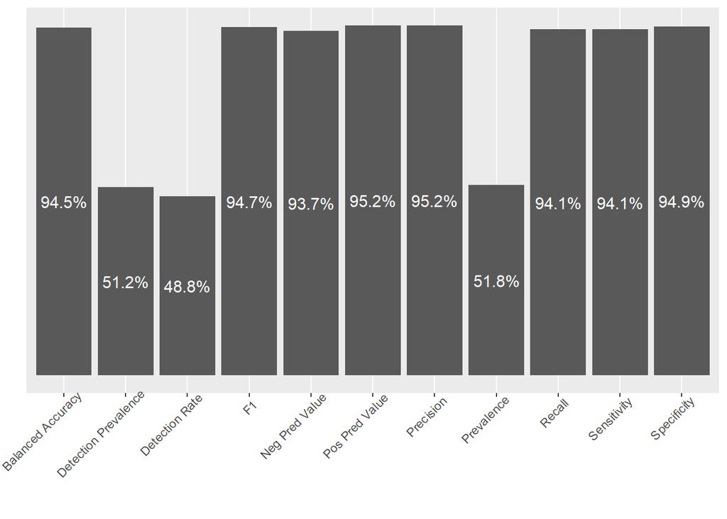

```
## rf variable importance
##
##             Overall
## LDH          100.00
## lymphocytes   28.59
## hs_CRP         0.00
```

## Future work

Poprzedni model opierał się o trzy atrybuty – LDH, hs-CRP i limfocyty, ponieważ zostały one wskazane w artykule dołączonym do zestawu danych.

Klasa śmiertelności pacjentów w zbiorze danych może być zależna od wielu czynników. Oto markery najbardziej skorelowane z atrybutem `outcome`.

|  | coeff |
| --- | --- |
| neutrophils(%) | 0.73 |
| (%)lymphocyte | -0.72 |
| albumin | -0.69 |
| Prothrombin.activity | -0.66 |
| High.sensitivity.C-reactive.protein | 0.65 |
| D-D.dimer | 0.64 |
| Lactate.dehydrogenase | 0.63 |
| neutrophils.count | 0.61 |
| Fibrin.degradation.products | 0.61 |
| calcium | -0.57 |

Współczynnik Pearsona w żadnym przypadku nie jest silny.

Kolejny klasyfikator mógłby opierać się o inny zestaw atrybutów, co mogłoby poprawić jego pracę.